# Scalar Measurement Invariance of the Hospital Cahps between Black and White Patients

R. Hass, M. Lanoue, A. Brecher, I. Dukulay, M. Li, P. Moeller, B. Oglesby

2024-06-24

#### Poster presented at the 2024 Academy Health Annual Research Meeting, Baltimore, MD

Here we present an extended supplement to the poster including content of all 15 items, percentage of missing data per item per race, and full details of MI testing.

## CAHPS Item Content

The following domains begin with the stem: *During this hospital Stay, how often…*

- Nurse Communication (3 items)
  - CMS_1_num: did nurses treat you with courtesy and respect?
  - CMS_2_num: did nurses listen carefully to you?
  - CMS_3_num: did nurses explain things in a way you could understand?
- Doctor Communication (3 items)
  - CMS_6_num: did doctors treat you with courtesy and respect?
  - CMS_7_num: did doctors listen carefully to you?
  - CMS_8_num: did doctors explain things in a way you could understand?
- Responsiveness of Staff (2 items)
  - CMS_37_num: after you pressed the call button, how often did you get help as soon as you wanted it?
  - CMS_13_num: get help in getting to the bathroom or in using a bedpan as soon as you wanted?
- Hospital Environment Composite (2 items)
  - CMS_10_num: were your room and bathroom kept clean?
  - CMS_11_num: was the area around your room quiet at night?
- Discharge Communication (2 items)
  - CMS_21_num: Did doctors, nurses or other hospital staff talk with you about whether you would have the help you needed when left the hospital?
  - CMS_22CL_num: Did you get information in writing about what symptoms or health problems to look out for after you left the hospital?

The next two are mixed stem items:

- Care Transitions (3 items) During this hospital stay, how often…
  - CMS_38_num: Staff took my preferences and those of my family or caregiver into account in deciding what my healthcare needs would be when I left When I left the hospital….
  - CMS_40_num: I clearly understood the purpose of taking each of my medications
  - CMS_39_num: I had a good understanding of the things I was responsible for in managing my health
- Medication Communication Composite (2 items) Before giving you any new medicine, how often did hospital staff….
  - CMS_19_num: tell you what the medicine was for?
  - CMS_33_num: describe possible side-effects of the medicine in a way you could understand?

## Analysis

### Missing Data

For simplicity, missing data was handled with casewise deletion. With a large N, this might not be problematic, especially with low proportion of missing data on most items. However, both medication communication items had ~30% missing responses, presumably due to patients not leaving with medication. This also applied to the medication item in the Care Transitions domain, albeit with fewer missing responses. Full response frequencies are presented below for Black and White patients.

Black Patients’ Response Proportions

```
## [[1]]
##
##
## |CMS_1_num |  Freq|
## |:---------|-----:|
## |2         | 0.027|
## |3         | 0.108|
## |4         | 0.854|
## |NA        | 0.011|
##
## [[2]]
##
##
## |CMS_2_num |  Freq|
## |:---------|-----:|
## |1         | 0.002|
## |2         | 0.039|
## |3         | 0.172|
## |4         | 0.778|
## |NA        | 0.009|
##
## [[3]]
##
##
## |CMS_3_num |  Freq|
## |:---------|-----:|
## |1         | 0.007|
## |2         | 0.033|
## |3         | 0.173|
## |4         | 0.769|
## |NA        | 0.018|
##
## [[4]]
##
##
## |CMS_6_num |  Freq|
## |:---------|-----:|
## |1         | 0.001|
## |2         | 0.022|
## |3         | 0.132|
```

[output cut: 104 more lines]

```
## |2          | 0.038|
## |3          | 0.421|
## |4          | 0.488|
## |NA         | 0.033|
##
## [[15]]
##
##
## |CMS_40_num |  Freq|
## |:----------|-----:|
## |1          | 0.022|
## |2          | 0.020|
## |3          | 0.311|
## |4          | 0.512|
## |NA         | 0.135|
```

White Patients’ Response Proportions

```
## [[1]]
##
##
## |CMS_1_num |  Freq|
## |:---------|-----:|
## |1         | 0.002|
## |2         | 0.024|
## |3         | 0.093|
## |4         | 0.869|
## |NA        | 0.012|
##
## [[2]]
##
##
## |CMS_2_num |  Freq|
## |:---------|-----:|
## |1         | 0.005|
## |2         | 0.036|
## |3         | 0.171|
## |4         | 0.775|
## |NA        | 0.013|
##
## [[3]]
##
##
## |CMS_3_num |  Freq|
## |:---------|-----:|
## |1         | 0.007|
## |2         | 0.038|
## |3         | 0.175|
## |4         | 0.766|
## |NA        | 0.014|
##
## [[4]]
##
##
## |CMS_6_num |  Freq|
## |:---------|-----:|
## |1         | 0.005|
## |2         | 0.024|
```

[output cut: 105 more lines]

```
## |2          | 0.036|
## |3          | 0.421|
## |4          | 0.495|
## |NA         | 0.029|
##
## [[15]]
##
##
## |CMS_40_num |  Freq|
## |:----------|-----:|
## |1          | 0.018|
## |2          | 0.024|
## |3          | 0.298|
## |4          | 0.503|
## |NA         | 0.157|
```

### Confirmatory Factor Analysis

# Invariance testing following Pendergast and doing casewise deletion

1. Configural = no constraints on the groups
2. Metric = loadings invariant
3. Scalar = thresholds and loadings invariant

| Model | $\chi^{2}$ | df | CFI | RMSEA | SRMR |
| --- | --- | --- | --- | --- | --- |
| Configural Model | 283.076 | 150 | 0.997 | 0.023 | 0.028 |
| Metric Model | 299.567 | 159 | 0.997 | 0.022 | 0.029 |
| Scalar Model | 305.102 | 166 | 0.997 | 0.022 | 0.029 |

# Figures

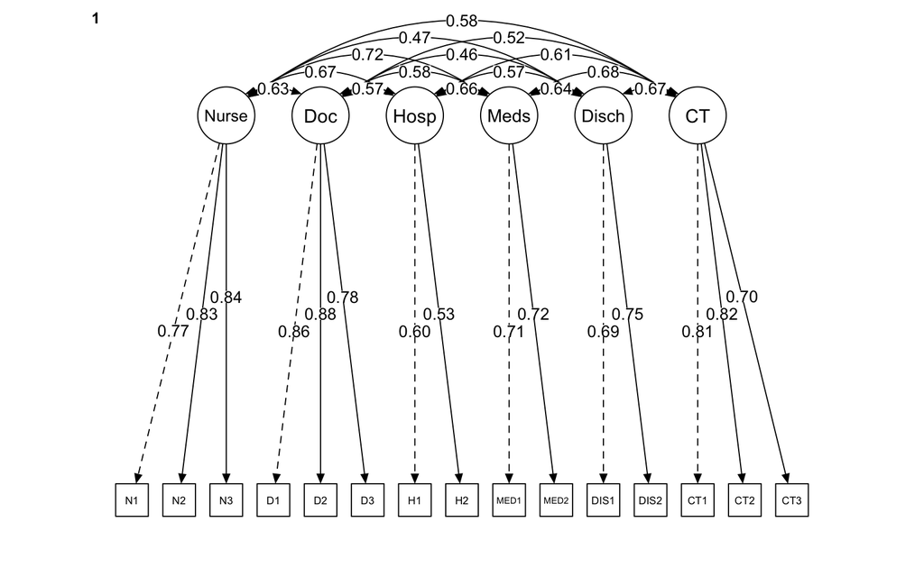

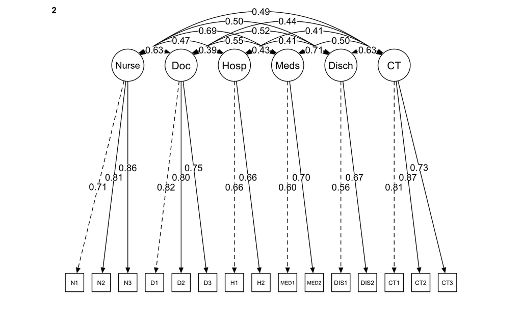